# Logistic Regression

## Objectives

- Use Logistic Regression for classification
- Preprocess data for modeling
- Implement Logistic regression on real world data

## Import needed packages

- Numpy
- Matplotlib
- Pandas
- Scikit-learn

Execute these cells to check if you have the above packages

```python
!pip install -q numpy pandas scikit-learn matplotlib
```

```python
import pandas as pd
import pandas as np

from sklearn.model_selection import train_test_split
from sklearn.linear_model import LogisticRegression
from sklearn.preprocessing import StandardScaler

from sklearn.metrics import log_loss
import matplotlib.pyplot as plt

%matplotlib inline

import warnings
warnings.filterwarnings('ignore')
```

### Scenario

Assume you are employed by a telecommunications firm that is worried about the increasing number of customers switching from its land-line services to cable competitors. They need to understand who is more likely to leave the company.

### Data

Telco Churn is a dataset developed to support a telecommunications company’s analysis of customer turnovers. Each observation represents an individual customer and includes demographic characteristics and service usage details.

### Load Data from URL

```python
churn_df = pd.read_csv("ChurnData.csv")
```

```python
churn_df
```

|  | tenure | age | address | income | ed | employ | equip | callcard | wireless | longmon | ... | pager | internet | callwait | confer | ebill | loglong | logtoll | lninc | custcat | churn |
| --- | --- | --- | --- | --- | --- | --- | --- | --- | --- | --- | --- | --- | --- | --- | --- | --- | --- | --- | --- | --- | --- |
| 0 | 11.0 | 33.0 | 7.0 | 136.0 | 5.0 | 5.0 | 0.0 | 1.0 | 1.0 | 4.40 | ... | 1.0 | 0.0 | 1.0 | 1.0 | 0.0 | 1.482 | 3.033 | 4.913 | 4.0 | 1.0 |
| 1 | 33.0 | 33.0 | 12.0 | 33.0 | 2.0 | 0.0 | 0.0 | 0.0 | 0.0 | 9.45 | ... | 0.0 | 0.0 | 0.0 | 0.0 | 0.0 | 2.246 | 3.240 | 3.497 | 1.0 | 1.0 |
| 2 | 23.0 | 30.0 | 9.0 | 30.0 | 1.0 | 2.0 | 0.0 | 0.0 | 0.0 | 6.30 | ... | 0.0 | 0.0 | 0.0 | 1.0 | 0.0 | 1.841 | 3.240 | 3.401 | 3.0 | 0.0 |
| 3 | 38.0 | 35.0 | 5.0 | 76.0 | 2.0 | 10.0 | 1.0 | 1.0 | 1.0 | 6.05 | ... | 1.0 | 1.0 | 1.0 | 1.0 | 1.0 | 1.800 | 3.807 | 4.331 | 4.0 | 0.0 |
| 4 | 7.0 | 35.0 | 14.0 | 80.0 | 2.0 | 15.0 | 0.0 | 1.0 | 0.0 | 7.10 | ... | 0.0 | 0.0 | 1.0 | 1.0 | 0.0 | 1.960 | 3.091 | 4.382 | 3.0 | 0.0 |
| ... | ... | ... | ... | ... | ... | ... | ... | ... | ... | ... | ... | ... | ... | ... | ... | ... | ... | ... | ... | ... | ... |
| 195 | 55.0 | 44.0 | 24.0 | 83.0 | 1.0 | 23.0 | 0.0 | 1.0 | 0.0 | 17.35 | ... | 0.0 | 0.0 | 0.0 | 1.0 | 0.0 | 2.854 | 3.199 | 4.419 | 3.0 | 0.0 |
| 196 | 34.0 | 23.0 | 3.0 | 24.0 | 1.0 | 7.0 | 0.0 | 1.0 | 0.0 | 6.00 | ... | 0.0 | 0.0 | 1.0 | 1.0 | 0.0 | 1.792 | 3.332 | 3.178 | 3.0 | 0.0 |
| 197 | 6.0 | 32.0 | 10.0 | 47.0 | 1.0 | 10.0 | 0.0 | 1.0 | 0.0 | 3.85 | ... | 0.0 | 0.0 | 1.0 | 1.0 | 0.0 | 1.348 | 3.168 | 3.850 | 3.0 | 0.0 |
| 198 | 24.0 | 30.0 | 0.0 | 25.0 | 4.0 | 5.0 | 0.0 | 1.0 | 1.0 | 8.70 | ... | 1.0 | 1.0 | 1.0 | 1.0 | 1.0 | 2.163 | 3.866 | 3.219 | 4.0 | 1.0 |
| 199 | 61.0 | 50.0 | 16.0 | 190.0 | 2.0 | 22.0 | 1.0 | 1.0 | 1.0 | 16.85 | ... | 0.0 | 1.0 | 0.0 | 0.0 | 1.0 | 2.824 | 3.240 | 5.247 | 2.0 | 0.0 |

200 rows × 28 columns

### Feature Selection

- Select some variables for modelling
- Target data type must be an integer

### Data preprocessing

Use a subset of the fields avaible to develop out model Assume : selected fields `age`, `tenure`, `address`, `income`, `ed`, `employ`, `equip` and `churn`.

```python
churn_df = churn_df[['tenure','age','address','income','ed','employ','equip','churn']]
churn_df['churn'] = churn_df['churn'].astype('int')
churn_df
```

|  | tenure | age | address | income | ed | employ | equip | churn |
| --- | --- | --- | --- | --- | --- | --- | --- | --- |
| 0 | 11.0 | 33.0 | 7.0 | 136.0 | 5.0 | 5.0 | 0.0 | 1 |
| 1 | 33.0 | 33.0 | 12.0 | 33.0 | 2.0 | 0.0 | 0.0 | 1 |
| 2 | 23.0 | 30.0 | 9.0 | 30.0 | 1.0 | 2.0 | 0.0 | 0 |
| 3 | 38.0 | 35.0 | 5.0 | 76.0 | 2.0 | 10.0 | 1.0 | 0 |
| 4 | 7.0 | 35.0 | 14.0 | 80.0 | 2.0 | 15.0 | 0.0 | 0 |
| ... | ... | ... | ... | ... | ... | ... | ... | ... |
| 195 | 55.0 | 44.0 | 24.0 | 83.0 | 1.0 | 23.0 | 0.0 | 0 |
| 196 | 34.0 | 23.0 | 3.0 | 24.0 | 1.0 | 7.0 | 0.0 | 0 |
| 197 | 6.0 | 32.0 | 10.0 | 47.0 | 1.0 | 10.0 | 0.0 | 0 |
| 198 | 24.0 | 30.0 | 0.0 | 25.0 | 4.0 | 5.0 | 0.0 | 1 |
| 199 | 61.0 | 50.0 | 16.0 | 190.0 | 2.0 | 22.0 | 1.0 | 0 |

200 rows × 8 columns

### Key Notes

For modelling the `input fields` X and the `target field` y, do the below.

- The target `churn` needs to be stored under the `variable y`
- The remaining input all combined stored in the `variable X`

```python
X = np.asarray(churn_df[['tenure','age','address','income','ed','employ','equip']])
X[:5]   # print the first 5 rows
```

```
array([[ 11.,  33.,   7., 136.,   5.,   5.,   0.],
       [ 33.,  33.,  12.,  33.,   2.,   0.,   0.],
       [ 23.,  30.,   9.,  30.,   1.,   2.,   0.],
       [ 38.,  35.,   5.,  76.,   2.,  10.,   1.],
       [  7.,  35.,  14.,  80.,   2.,  15.,   0.]])
```

```python
y = np.asarray(churn_df['churn'])
y[0:5] # print the first 5 values
```

```
array([1, 1, 0, 0, 0])
```

- Standardize the dataset to get all the features as the same scale
- Use StandardScalar function

```python
X_norm = StandardScaler().fit(X).transform(X)
X_norm[0:5]
```

```
array([[-1.13518441, -0.62595491, -0.4588971 ,  0.4751423 ,  1.6961288 ,
        -0.58477841, -0.85972695],
       [-0.11604313, -0.62595491,  0.03454064, -0.32886061, -0.6433592 ,
        -1.14437497, -0.85972695],
       [-0.57928917, -0.85594447, -0.261522  , -0.35227817, -1.42318853,
        -0.92053635, -0.85972695],
       [ 0.11557989, -0.47262854, -0.65627219,  0.00679109, -0.6433592 ,
        -0.02518185,  1.16316   ],
       [-1.32048283, -0.47262854,  0.23191574,  0.03801451, -0.6433592 ,
         0.53441472, -0.85972695]])
```

### Spliting the dataset

- Data must be set aside for testing hence the need to split the data into training and testing dataset.
- Use train_test_split

```python
X_train, X_test, y_train, y_test = train_test_split(X_norm, y, test_size=0.2, random_state=4)
```

### Logistic Regression Classifier Modelling

- Build the model using LogisticRegression from the Scikit-learn package
- fit our model with train data set.

```python
LR = LogisticRegression().fit(X_train, y_train)
print("Coefficients:", LR.coef_)
print("Intercept:", LR.intercept_)
```

```
Coefficients: [[-0.84569763 -0.17566042 -0.12422107 -0.01015039  0.06012391 -0.23290551
   0.75198953]]
Intercept: [-1.47113611]
```

### Interpretation

We trained a logistic regression model to predict which telecom customers are likely to churn. Key results:

- **Intercept:** -1.471
- **Coefficients:**
  - tenure: -0.846
  - age: -0.176
  - address: -0.124
  - income: -0.010
  - ed: 0.060
  - employ: -0.233
  - equip: 0.752
- **Interpretation:**
  - Negative coefficients (`tenure`, `age`, `address`, `income`, `employ`) → reduce the likelihood of churn
  - Positive coefficients (`ed`, `equip`) → increase the likelihood of churn
  - Negative intercept → overall baseline probability of churn is low

```python
# the traning data and can be used to predict the output variable.
#Let us predict the churn parameter for the test data set.

yhat = LR.predict(X_test)
yhat[:10]
```

```
array([0, 0, 0, 0, 0, 0, 0, 0, 1, 0])
```

### Understanding Prediction Probabilities

To better understand the predictions from the logistic regression model:

- We can look at the **prediction probability** for a data point in the test dataset.
- Use the function `predict_proba()` to get the probability of each class.
- The output is an **array with two columns**:
  - **First column:** probability that the record belongs to **class 0** (stay)
  - **Second column:** probability that the record belongs to **class 1** (churn)
- The class prediction system uses a **threshold of 0.5**:
  - If the probability of class 1 ≥ 0.5 → predicted class = 1
  - Otherwise → predicted class = 0
- This means the model always predicts the **most likely class** for each data point.

```python
yhat_prob = LR.predict_proba(X_test)
yhat_prob[:10]
```

```
array([[0.74643946, 0.25356054],
       [0.92667894, 0.07332106],
       [0.83442627, 0.16557373],
       [0.94600618, 0.05399382],
       [0.84325532, 0.15674468],
       [0.71448367, 0.28551633],
       [0.77076426, 0.22923574],
       [0.90955642, 0.09044358],
       [0.26152115, 0.73847885],
       [0.94900731, 0.05099269]])
```

Examine what role each input feature has to play in the prediction of the 1 class.use the code below

**`pd.Series(LR.coef_[0], index=churn_df.columns[:-1])`**

*Creates a pandas Series mapping each feature to its logistic regression coefficient.*

**`LR.coef_[0]`** contains the coefficients learned by the model.

**`churn_df.columns[:-1]`** ensures the coefficients are matched to the feature names (excluding the target).

**`coefficients.sort_values().plot(kind='barh')`**

Sorts the coefficients and plots them as a horizontal bar chart.*

**`plt.title(), plt.xlabel(), plt.show()`**

Adds a title, label, and displays the plot.

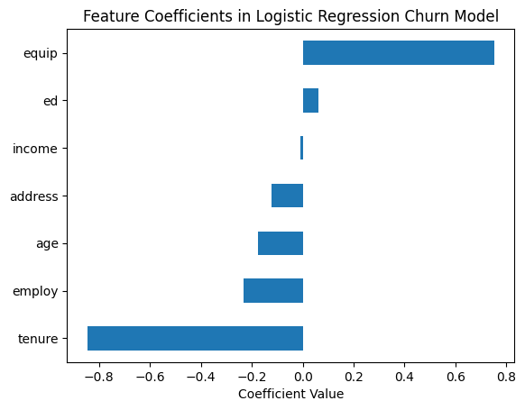

```python
coefficients = pd.Series(LR.coef_[0], index=churn_df.columns[:-1])
coefficients.sort_values().plot(kind='barh')
plt.title("Feature Coefficients in Logistic Regression Churn Model")
plt.xlabel("Coefficient Value")
plt.show()
```

### Performance Evaluation

Evaluate the model's performance in predicting the target variable. Do it by evaluating the log-loss value

### Log Loss

Log loss (Logarithmic loss) measures the difference between the predicted probabilities and the actual class labels.

- In our case, the **class labels** are the target variable `Churn`:
  - `0` → customer **stayed**
  - `1` → customer **churned**
- A **lower log loss value** indicates a **better performing model**.
- It takes into account the probability assigned to each class, not just the final predicted class.

```python
log_loss(y_test, yhat_prob)
```

```
0.6257718410257235
```

## Summary of Logistic Regression Analysis

- A **logistic regression model** was trained to predict customer churn (`0` = stayed, `1` = churned).
- **Key features** influencing churn include `tenure`, `age`, `address`, `income`, `ed`, `employ`, and `equip`.
- **Prediction probabilities** were generated using `predict_proba()`, with a threshold of 0.5 for class prediction.
- **Feature coefficients** show which factors increase or decrease the likelihood of churn.
- **Model performance** was evaluated using **log loss**, with a value of **0.626**, indicating the model reasonably predicts churn probabilities.